# Linear Mixed Models

IDC 6940

BDP: Bess T., Dasia M., Preethi R.

## Covariance Structure

Covariance measures joint variability — the extent of variation between two random variables.

It is similar to variance, but while variance quantifies the variability of a single variable, covariance quantifies how two variables vary together.

The measure can be positive, negative, or zero:

• Positive covariance = an overall tendency for variables to move together. Data points will trend upwards on a graph.

covariance has no limitations on its values, which can make it challenging to interpret.

## Covariance Structure continued..

- What is Covariance structure ?

  In a mixed model, a covariance structure describes the pattern of correlations between repeated measurements taken on the same subject, essentially defining how the errors within a group (like individuals in a study) are related to each other, allowing for more accurate analysis of data with clustered or hierarchical structures, especially when dealing with longitudinal or repeated measures data
- Why is it necessary for modeling repeated measures?

  Modeling repeated measures in mixed models is necessary because when you have multiple observations taken from the same subject over time, these observations are likely to be correlated with each other, and a standard linear regression model that assumes independence of observations would not accurately account for this correlation, potentially leading to unreliable results;

mixed models allow you to explicitly model this within-subject dependence by incorporating random effects specific to each individual, providing a more accurate analysis of the data

## Mixed Models for Repeated Measures

Cluster randomized trials (CRTs) are a design used to test interventions where individual randomization is not appropriate.

The mixed model for repeated measures (MMRM) is a popular choice for individually randomized trials with longitudinal continuous outcomes.

This model’s appeal is due to avoidance of model misspecification and its unbiasedness for data missing completely at random or at random.

Cluster randomized trials with longitudinally measured outcomes have two sources of non-independence: the cluster and the repeated measures over time.

Linear mixed-effects models are one option for handling the non-independence of measurements over time.

In the mixed-model context, one may use a random-coefficients model, using random effects for a subject’s intercept and sometimes slope.

Alternatively, one may use covariance pattern models, where the covariance between repeated measures on the same subject is modeled explicitly from the residual effects.

The mixed model for repeated measures uses an unstructured time and covariance structure.

- Unstructured time means that time is modeled categorically, rather than continuously as a linear or polynomial function, and allows for an arbitrary trajectory over time.
- While the continuous time models may use fewer degrees of freedom and may, therefore, be more powerful, it can be difficult to anticipate the outcome’s time trajectory in advance.

## Robust Estimation

What is Robust Estimation?

- Robust estimation refers to statistical methods designed to provide reliable parameter estimates even when the data contains outliers or deviations from standard assumptions (such as normality).
- These methods aim to minimize the influence of such outliers, which can significantly distort the results of traditional statistical techniques.
- Robust estimators are less sensitive to extreme values or outliers, providing estimates that are more representative of the majority of the data.
- Robust methods typically have a high breakdown point, meaning they can handle a significant percentage of outliers without breaking down.

What is Non-Robust Estimation?

- Non-robust estimation refers to traditional statistical methods that assume the data are free from outliers or adhere strictly to specified distributions.
- These methods can produce unreliable estimates when the data contain outliers.
- Non-robust methods, such as ordinary least squares (OLS) regression, can be heavily influenced by a small number of extreme values, leading to biased or misleading results.
- These methods typically have a lower breakdown point, meaning that even a small proportion of outliers can lead to failure in obtaining valid estimates. Non-robust estimators often rely on strict assumptions regarding the underlying data distribution, such as normality or homoscedasticity.

## Robust methods

- Robust methods are preferred in situations where data may contain outliers or when the underlying assumptions are violated.
- Non-robust methods are typically more efficient under ideal conditions (no outliers and met assumptions).
- In the presence of outliers, robust estimators maintain consistent performance, while non-robust estimators may yield skewed or incorrect results.

## References

- Agostinelli, C., & Yohai, V. J. (2016). Composite robust estimators for linear mixed models. *Journal of the American Statistical Association*, 111(516), 1764-1774. https://doi.org/10.1080/01621459.2015.1115358
- Bates, D. (2014). Fitting linear mixed-effects models using lme4. arXiv preprint arXiv:1406.5823.
- Baayen, R. H., Davidson, D. J., & Bates, D. M. (2008). Mixed-effects modeling with crossed random effects for subjects and items. *Journal of Memory and Language*, 59(4), 390-412.
- Barr, D. J., Levy, R., Scheepers, C., & Tily, H. J. (2013). Random effects structure for confirmatory hypothesis testing: Keep it maximal. *Journal of Memory and Language*, 68(3), 255-278.
- Bruin, J. (2006). newtest: command to compute new test. UCLA: Statistical Consulting Group. https://stats.oarc.ucla.edu/stata/ado/analysis/.

## References (continued)

- Enders, C. K. (2010). *Applied Missing Data Analysis*. Guilford Press.
- Gelman, A., & Hill, J. (2007). *Data Analysis Using Regression and Multilevel/Hierarchical Models*. Cambridge University Press.
- Starkweather, J. (2010). Linear mixed effects modeling using R. Unpublished Manuscript.
- Fitzmaurice GM, Laird NM, Ware JH. Applied longitudinal analysis. 2nd ed. Hoboken: Wiley; 2011.
- https://trialsjournal.biomedcentral.com/articles/10.1186/s13063-020-4114-9#:~:text=This%20model%20induces%20a%20compound,and%20%CF%832w%20=%2090.&text=The%20third%20data%2Dsimulation%20method,in%20the%20Additional%20file%201.

## Dataset: OASIS-Longitudinal MRI Data in Nondemented and Demented Older Adults

source: https://www.ncbi.nlm.nih.gov/pmc/articles/PMC2895005/

summary of the chosen dataset:

- The dataset includes MRI scans of 150 subjects, aged 60-96, collected longitudinally over 373 sessions.
- Subjects scanned at least twice, with visits separated by a year or more, using the same MRI scanner.
- Clinical Dementia Rating (CDR) categorized as nondemented or with very mild to mild Alzheimer’s disease.
- 72 were nondemented throughout the study, while 64 were demented at the initial visit and remained so.
- They were right-handed, consisting of 62 men and 88 women, with 3-4 T1-weighted MRI scans per session.

## R script for table1

```r
#install.packages("tableone")
library(tableone)

#install.packages("readr")
library(readr)

oasis_longitudinal <- read_csv("oasis_longitudinal.csv")

# Load necessary library
library(tableone)

# Recode M/F for easier handling in Table 1 (optional)
oasis_longitudinal$Gender <- ifelse(oasis_longitudinal$'M/F' == "M", "Male", "Female")

# Define the variables to be included in Table 1
vars <- c("Age", "Gender", "Hand", "EDUC", "SES", "MMSE", "CDR", "eTIV", "nWBV", "ASF")

# Define the stratifying variable (Group)
strata <- "Group"

# Create Table 1
table1 <- CreateTableOne(vars = vars, strata = strata, data = oasis_longitudinal, factorVars = c("Gender", "Hand", "CDR"))

# Print the table with p-values
print(table1, showAllLevels = TRUE, smd = TRUE)
```

```
                  Stratified by Group
                   level  Converted        Demented         Nondemented
  n                            37              146              190
  Age (mean (SD))           79.76 (7.43)     76.26 (6.94)     77.06 (8.10)
  Gender (%)       Female      24 ( 64.9)       60 ( 41.1)      129 ( 67.9)
                   Male        13 ( 35.1)       86 ( 58.9)       61 ( 32.1)
  Hand (%)         R           37 (100.0)      146 (100.0)      190 (100.0)
  EDUC (mean (SD))          15.46 (2.52)     13.67 (2.90)     15.14 (2.74)
  SES (mean (SD))            1.73 (0.96)      2.77 (1.20)      2.39 (1.05)
  MMSE (mean (SD))          28.68 (1.56)     24.51 (4.50)     29.23 (0.88)
  CDR (%)          0           18 ( 48.6)        0 (  0.0)      188 ( 98.9)
                   0.5         19 ( 51.4)      102 ( 69.9)        2 (  1.1)
                   1            0 (  0.0)       41 ( 28.1)        0 (  0.0)
                   2            0 (  0.0)        3 (  2.1)        0 (  0.0)
  eTIV (mean (SD))        1459.27 (135.43) 1485.85 (173.77) 1495.50 (184.89)
  nWBV (mean (SD))           0.72 (0.04)      0.72 (0.03)      0.74 (0.04)
  ASF (mean (SD))            1.21 (0.11)      1.20 (0.14)      1.19 (0.14)
                  Stratified by Group
                   p      test SMD
  n
  Age (mean (SD))   0.045       0.313
  Gender (%)       <0.001       0.371

  Hand (%)             NA      <0.001
  EDUC (mean (SD)) <0.001       0.433
  SES (mean (SD))  <0.001       0.652
  MMSE (mean (SD)) <0.001       1.041
  CDR (%)          <0.001       5.599



  eTIV (mean (SD))  0.510       0.149
  nWBV (mean (SD)) <0.001       0.465
  ASF (mean (SD))   0.683       0.111
```

## Table1

|  | level | Converted | Demented | Nondemented | p |
| --- | --- | --- | --- | --- | --- |
| n |  | 37 | 146 | 190 |  |
| Female | F | 24 ( 64.9) | 60 ( 41.1) | 129 ( 67.9) | <0.001 |
| Male | M | 13 ( 35.1) | 86 ( 58.9) | 61 ( 32.1) |  |
| Dom Hand | R | 37 (100.0) | 146 (100.0) | 190 (100.0) | NA |
| CDR | 0 | 18 ( 48.6) | 0 ( 0.0) | 188 ( 98.9) | <0.001 |
|  | 0.5 | 19 ( 51.4) | 102 ( 69.9) | 2 ( 1.1) |  |
|  | 1 | 0 ( 0.0) | 41 ( 28.1) | 0 ( 0.0) |  |
|  | 2 | 0 ( 0.0) | 3 ( 2.1) | 0 ( 0.0) |  |
| Age |  | 79.76 (7.43) | 76.26 (6.94) | 77.06 (8.10) | 0.045 |
| Education |  | 15.46 (2.52) | 13.67 (2.90) | 15.14 (2.74) | <0.001 |
| SES |  | 1.73 (0.96) | 2.77 (1.20) | 2.39 (1.05) | <0.001 |
| MMSE |  | 28.68 (1.56) | 24.51 (4.50) | 29.23 (0.88) | <0.001 |
| eTIV |  | 1459.27 (135.43) | 1485.85 (173.77) | 1495.50 (184.89) | 0.51 |
| nWBV |  | 0.72 (0.04) | 0.72 (0.03) | 0.74 (0.04) | <0.001 |
| ASF |  | 1.21 (0.11) | 1.20 (0.14) | 1.19 (0.14) | 0.683 |

## Data Visualizations

## Age of Participants

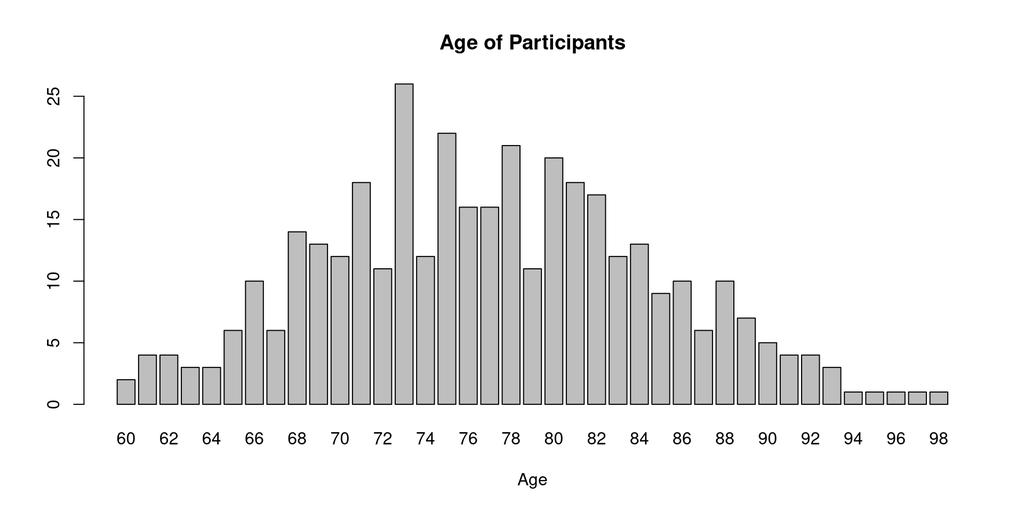

## Count of Clinical Dementia Rating

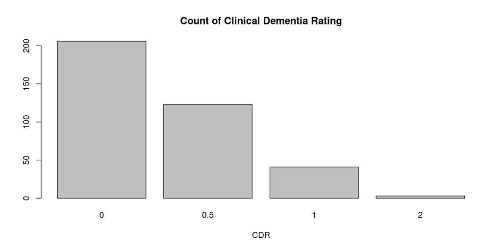

## Gender of Participants

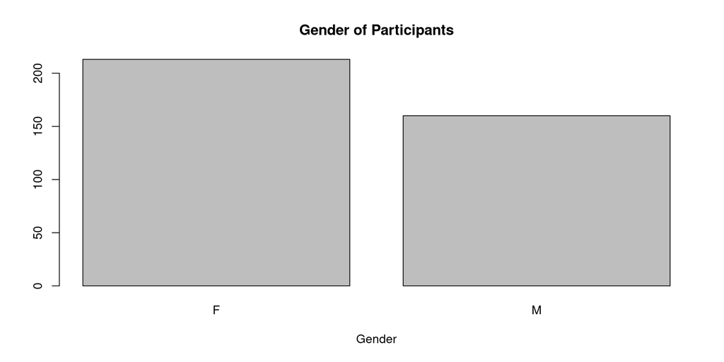

## Socio Economic Status of Participants

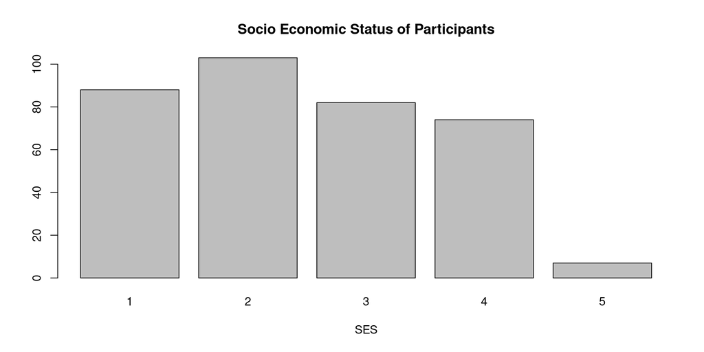

## Demented Status of Participants

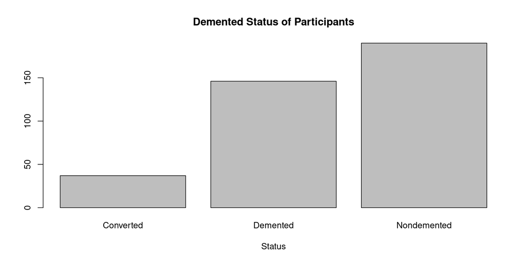

## Total number of visits for each Participant

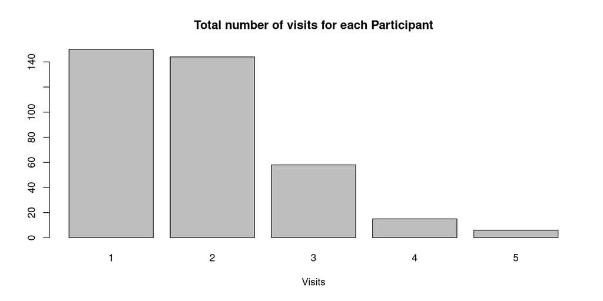

## Estimated Total Intracranial Volume vs Age

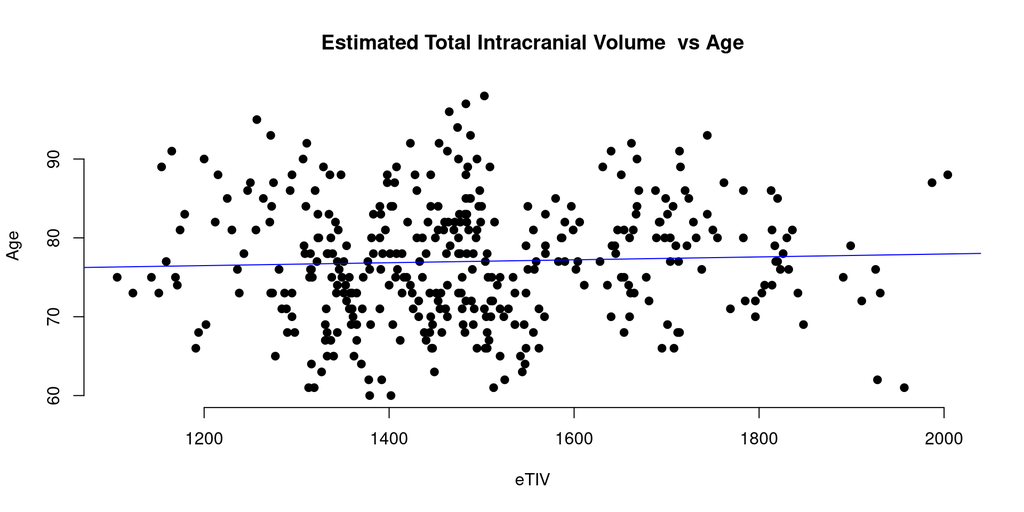

## Normalize Whole Brain Volume vs Age

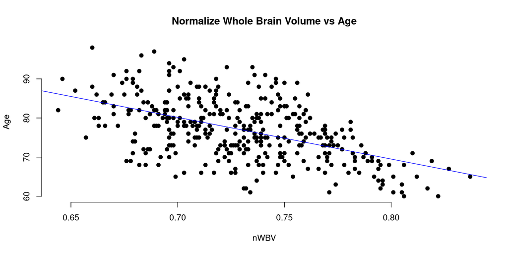

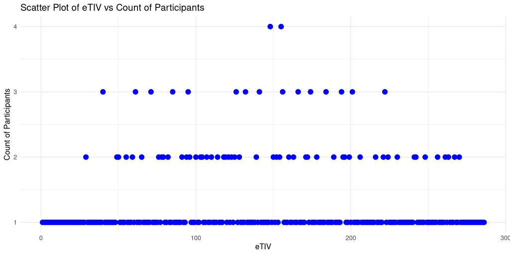

## Individual Analysis

How various cognitive and brain volume measures (nWBV) are influenced by factors such as age and socio economic status

by Preethi Ravikumar

## Goal

The goal is to understand how various cognitive and brain volume measures (e.g., MMSE, CDR, eTIV, nWBV) are influenced by factors such as age, sex, education, or group (demented vs. nondemented) while accounting for repeated measures (longitudinal data).

## Fitting the Linear Mixed Model:

● Outcome: nWBV (Normalized Whole Brain Volume) – representing structural brain changes over time.

● Primary Predictor: Age to see if aging correlates with changes in brain volume.

● Secondary Predictor: Socioeconomic Status (SES) to observe if socioeconomic factors impact brain volume over time.

● Fixed Effects: Age and Socioeconomic Status (SES).

● Random Effects: Subject.ID.

```r
#install.packages("readr")
library(readr)
oasis_data <- read_csv("oasis_longitudinal.csv")
```

## R Script for fitting linear mixed Model:

```r
#install.packages("lme4")
library(lme4)

oasis_data$gender <- oasis_data$'M/F'
oasis_data$SubjectID <- oasis_data$'Subject ID'

# Fit Linear Mixed Model
model <- lmer(nWBV ~ Age + SES + (1 | SubjectID), data = oasis_data)
summary(model)
```

```
Linear mixed model fit by REML ['lmerMod']
Formula: nWBV ~ Age + SES + (1 | SubjectID)
   Data: oasis_data

REML criterion at convergence: -1842.3

Scaled residuals:
    Min      1Q  Median      3Q     Max
-4.0215 -0.4692  0.0140  0.4432  3.6478

Random effects:
 Groups    Name        Variance  Std.Dev.
 SubjectID (Intercept) 0.0010160 0.031874
 Residual              0.0000697 0.008349
Number of obs: 354, groups:  SubjectID, 142

Fixed effects:
              Estimate Std. Error t value
(Intercept)  0.9956305  0.0183229  54.338
Age         -0.0034846  0.0002211 -15.761
SES          0.0008823  0.0024137   0.366

Correlation of Fixed Effects:
    (Intr) Age
Age -0.933
SES -0.342  0.015
```

## Maximum Likelihood

```r
# Fit the model with ML for model comparison
model_ml <- lmer(nWBV ~ Age + SES + (1 | SubjectID), data = oasis_data, REML = FALSE)
summary(model_ml)
```

```
Linear mixed model fit by maximum likelihood  ['lmerMod']
Formula: nWBV ~ Age + SES + (1 | SubjectID)
   Data: oasis_data

     AIC      BIC   logLik deviance df.resid
 -1867.5  -1848.2    938.8  -1877.5      349

Scaled residuals:
    Min      1Q  Median      3Q     Max
-4.0300 -0.4722  0.0137  0.4444  3.6503

Random effects:
 Groups    Name        Variance  Std.Dev.
 SubjectID (Intercept) 9.979e-04 0.031589
 Residual              6.953e-05 0.008338
Number of obs: 354, groups:  SubjectID, 142

Fixed effects:
              Estimate Std. Error t value
(Intercept)  0.9952308  0.0182348  54.579
Age         -0.0034795  0.0002202 -15.804
SES          0.0008834  0.0023926   0.369

Correlation of Fixed Effects:
    (Intr) Age
Age -0.933
SES -0.341  0.015
```

## Results for Maximum Likelihood:

Random Effects:

• (Intercept) Variance: 0.0009979 (Standard Deviation: 0.0316) This is the variability in nWBV across different subjects. The random intercept accounts for individual differences in baseline nWBV.

• Residual Variance: 0.00006953 (Standard Deviation: 0.00834) This is the remaining variance in nWBV after accounting for both fixed and random effects.

Fixed Effects:

• Intercept: 0.9952. This is the estimated baseline nWBV when Age and SES are zero. In your model, it likely represents an estimated baseline close to 1.

• Age: -0.00348. This negative estimate suggests that nWBV decreases with increasing age. Specifically, for each one-unit increase in Age, nWBV is expected to decrease by about 0.00348 units, holding SES constant.

• t value: -15.804 (a high magnitude t-value, suggesting Age is statistically significant)

• SES: 0.00088. This positive coefficient suggests that as SES increases, there’s a very slight increase in nWBV. However, given the low t-value (0.369), SES may not have a statistically significant effect on nWBV in this model.

Summary Interpretation:

• SES appears to have little to no significant effect on nWBV based on this model.

## REML

```r
# Fit the model with REML (default)
model_reml <- lmer(nWBV ~ Age + SES + (1 | SubjectID), data = oasis_data, REML = TRUE)
summary(model_reml)
```

```
Linear mixed model fit by REML ['lmerMod']
Formula: nWBV ~ Age + SES + (1 | SubjectID)
   Data: oasis_data

REML criterion at convergence: -1842.3

Scaled residuals:
    Min      1Q  Median      3Q     Max
-4.0215 -0.4692  0.0140  0.4432  3.6478

Random effects:
 Groups    Name        Variance  Std.Dev.
 SubjectID (Intercept) 0.0010160 0.031874
 Residual              0.0000697 0.008349
Number of obs: 354, groups:  SubjectID, 142

Fixed effects:
              Estimate Std. Error t value
(Intercept)  0.9956305  0.0183229  54.338
Age         -0.0034846  0.0002211 -15.761
SES          0.0008823  0.0024137   0.366

Correlation of Fixed Effects:
    (Intr) Age
Age -0.933
SES -0.342  0.015
```

## Results for REML:

Random Effects:

• (Intercept) Variance: 0.001016 (Standard Deviation: 0.03187). The variance estimate for the random intercept has changed slightly from the ML output (from 0.0009979 to 0.001016), reflecting REML’s slightly different handling of variance components.

• Residual Variance: 0.0000697 (Standard Deviation: 0.008349). This value is nearly identical to the ML result, indicating minimal change in the residual variance under REML.

Fixed Effects:

• (Intercept): 0.9956. This represents the estimated baseline nWBV when Age and SES are zero. The intercept estimate is nearly unchanged from the ML estimate.

• Age: -0.00348. The negative coefficient for Age is consistent with the ML output, indicating a similar estimated decline in nWBV with increasing age.

• t value: -15.761 (also very similar to the ML result, suggesting that Age is a highly significant predictor)

• SES: 0.00088. This coefficient remains small and statistically insignificant, indicating little to no effect of SES on nWBV in this model.

## Comparison of the two methods:

• Fixed Effects: The estimates for Age and SES under REML are nearly identical to those under ML, showing consistent results.

• SES appears to have little to no significant effect on nWBV.

In summary, REML is appropriate for final model interpretation as it provides the better estimates for variance components, while both methods confirm Age as a key predictor of nWBV decline.